# Reproducible Research: Peer Assessment 1

The present work uses data about personal movement, collected using activity monitoring devices.

```r
## Configuration
# install.packages("reactable")
# install.packages("ggplot2")
# install.packages("patchwork")

library(reactable)
library(ggplot2)
library(patchwork)
```

## Loading and preprocessing the data

First of all we need to load the data:

```r
dataset <- read.csv(unz("activity.zip","activity.csv"), header=TRUE)
```

Let’s see how it looks like:

```r
head(dataset)
```

```
##   steps       date interval
## 1    NA 2012-10-01        0
## 2    NA 2012-10-01        5
## 3    NA 2012-10-01       10
## 4    NA 2012-10-01       15
## 5    NA 2012-10-01       20
## 6    NA 2012-10-01       25
```

Oh, *date* ttribute was loaded with type *character*. We need to change it:

```r
dataset$date <- as.Date(dataset$date, format = "%Y-%m-%d")
```

And now:

```r
head(dataset)
```

```
##   steps       date interval
## 1    NA 2012-10-01        0
## 2    NA 2012-10-01        5
## 3    NA 2012-10-01       10
## 4    NA 2012-10-01       15
## 5    NA 2012-10-01       20
## 6    NA 2012-10-01       25
```

The firsts observations of *steps* are *NA*. Does it happen at the end?

```r
tail(dataset)
```

```
##       steps       date interval
## 17563    NA 2012-11-30     2330
## 17564    NA 2012-11-30     2335
## 17565    NA 2012-11-30     2340
## 17566    NA 2012-11-30     2345
## 17567    NA 2012-11-30     2350
## 17568    NA 2012-11-30     2355
```

Let’s get some more information about the dataset:

```r
str(dataset)
```

```
## 'data.frame':    17568 obs. of  3 variables:
##  $ steps   : int  NA NA NA NA NA NA NA NA NA NA ...
##  $ date    : Date, format: "2012-10-01" "2012-10-01" ...
##  $ interval: int  0 5 10 15 20 25 30 35 40 45 ...
```

We have a total of 17568 observations (exactly as informed on the project page), with 3 attributes. Now, some statistical information:

```r
summary(dataset)
```

```
##      steps             date               interval
##  Min.   :  0.00   Min.   :2012-10-01   Min.   :   0.0
##  1st Qu.:  0.00   1st Qu.:2012-10-16   1st Qu.: 588.8
##  Median :  0.00   Median :2012-10-31   Median :1177.5
##  Mean   : 37.38   Mean   :2012-10-31   Mean   :1177.5
##  3rd Qu.: 12.00   3rd Qu.:2012-11-15   3rd Qu.:1766.2
##  Max.   :806.00   Max.   :2012-11-30   Max.   :2355.0
##  NA's   :2304
```

Oh, *steps* attribute really have a lot of *NA*. The *date* starts in 2012-10-01 and goes to 2012-11-30. Nothing special about *interval*.

From the Coursera project page we have some information about the attributes:

> steps: Number of steps taking in a 5-minute interval (missing values are coded as NA)

> date: The date on which the measurement was taken in YYYY-MM-DD format

> interval: Identifier for the 5-minute interval in which measurement was taken

If I was able to understand, for each *date*, we have for each 5 minute *interval* a measurement of number of *steps*.

Let’s see the full dataset, so we can go through the data.

```r
reactable(dataset,
          defaultColDef = colDef(align = "center"),
          bordered = TRUE,
          highlight = TRUE)
```

| steps | date | interval |
| --- | --- | --- |
| NA | 2012-10-01 | 0 |
| NA | 2012-10-01 | 5 |
| NA | 2012-10-01 | 10 |
| NA | 2012-10-01 | 15 |
| NA | 2012-10-01 | 20 |
| NA | 2012-10-01 | 25 |
| NA | 2012-10-01 | 30 |
| NA | 2012-10-01 | 35 |
| NA | 2012-10-01 | 40 |
| NA | 2012-10-01 | 45 |

[output cut: 17558 more lines]

I think I got it right, for the same day we have a lot of five minutes time intervals, for each one we have the total of steps.

## What is mean total number of steps taken per day?

To count the total number of steps taken per day, we have to aggregate the dataset by date, summing the number of steps.

```r
## remove NA
temp <- dataset[!(is.na(dataset$steps)), ]

## aggregates the data
steps_day <- aggregate(temp$steps, list(temp$date), FUN=sum)
colnames(steps_day) <- c("date", "steps")
```

Let’s see the resulting values:

```r
reactable(steps_day,
          defaultColDef = colDef(align = "center"),
          bordered = TRUE,
          highlight = TRUE)
```

| date | steps |
| --- | --- |
| 2012-10-02 | 126 |
| 2012-10-03 | 11352 |
| 2012-10-04 | 12116 |
| 2012-10-05 | 13294 |
| 2012-10-06 | 15420 |
| 2012-10-07 | 11015 |
| 2012-10-09 | 12811 |
| 2012-10-10 | 9900 |
| 2012-10-11 | 10304 |
| 2012-10-12 | 17382 |

[output cut: 43 more lines]

The following figure presents a histogram of the total number of steps taken by day.

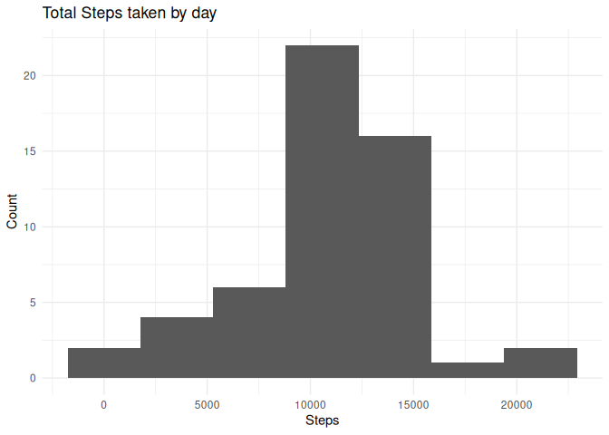

```r
ggplot(steps_day, aes(steps)) +
  geom_histogram(bins=7) +
  labs(title = "Total Steps taken by day",
       x = "Steps",
       y = "Count") +
  theme_minimal()
```

The mean and median of total number of steps cam be taken in different ways. The *summary* command:

```r
summary(steps_day$steps)
```

```
##    Min. 1st Qu.  Median    Mean 3rd Qu.    Max.
##      41    8841   10765   10766   13294   21194
```

Or using a command for each information:

- *mean()* - with result: 1.0766189^{4}
- *median()* - with result: 10765

## What is the average daily activity pattern?

This time we have to aggregate by the *interval*.

```r
## remove NA
temp <- dataset[!(is.na(dataset$steps)), ]

## aggregates the data
steps_interval <- aggregate(temp$steps, list(temp$interval), FUN=mean)
colnames(steps_interval) <- c("interval", "steps")
```

Let’s see the time series of the average of steps, by time interval:

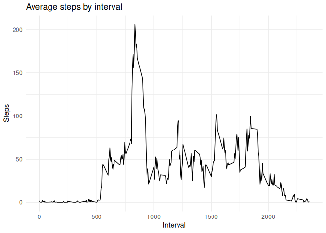

```r
ggplot(steps_interval, aes(interval, steps)) +
  geom_line() +
  labs(title = "Average steps by interval",
       x = "Interval",
       y = "Steps") +
  theme_minimal()
```

## Imputing missing values

We had already seen that only *steps* attribute has *NA* values. We used the following command:

```r
summary(dataset)
```

```
##      steps             date               interval
##  Min.   :  0.00   Min.   :2012-10-01   Min.   :   0.0
##  1st Qu.:  0.00   1st Qu.:2012-10-16   1st Qu.: 588.8
##  Median :  0.00   Median :2012-10-31   Median :1177.5
##  Mean   : 37.38   Mean   :2012-10-31   Mean   :1177.5
##  3rd Qu.: 12.00   3rd Qu.:2012-11-15   3rd Qu.:1766.2
##  Max.   :806.00   Max.   :2012-11-30   Max.   :2355.0
##  NA's   :2304
```

As it is possible to see, *date* and *interval* do no have any *NA*. But the number of missing values in the dataset can be obtained like:

```r
total_na <- sum(is.na(dataset$steps)) + sum(is.na(dataset$date)) + sum(is.na(dataset$interval))

print(paste0("The total of NA values is: ", total_na))
```

```
## [1] "The total of NA values is: 2304"
```

But there is an important observation at the course project page: “…(i.e. the total number of rows with NA)”. This way a *NA* could occur in two attributes on the same observation and count as a unique occurrence:

```r
print(paste0("Total rows with at least one NA: ", nrow(dataset[is.na(dataset$steps) | is.na(dataset$date) | is.na(dataset$interval), ])))
```

```
## [1] "Total rows with at least one NA: 2304"
```

As a strategy for filling in all of the missing values in the dataset, we could use the mean of the time interval through the days. Let’s do it:

```r
filled_dataset <- dataset
for (i in 1:nrow(dataset)) {
  if (is.na(filled_dataset[i, "steps"])) {
    interval <- filled_dataset[i, "interval"]
    filled_dataset[i, "steps"] <- steps_interval[steps_interval$interval==interval, "steps"]
  }
}
```

Now we can chek it:

```r
summary(filled_dataset)
```

```
##      steps             date               interval
##  Min.   :  0.00   Min.   :2012-10-01   Min.   :   0.0
##  1st Qu.:  0.00   1st Qu.:2012-10-16   1st Qu.: 588.8
##  Median :  0.00   Median :2012-10-31   Median :1177.5
##  Mean   : 37.38   Mean   :2012-10-31   Mean   :1177.5
##  3rd Qu.: 27.00   3rd Qu.:2012-11-15   3rd Qu.:1766.2
##  Max.   :806.00   Max.   :2012-11-30   Max.   :2355.0
```

```r
## aggregates the data
steps_day <- aggregate(temp$steps, list(temp$date), FUN=sum)
colnames(steps_day) <- c("date", "steps")
```

The following figure presents a histogram of the total number of steps taken by day.

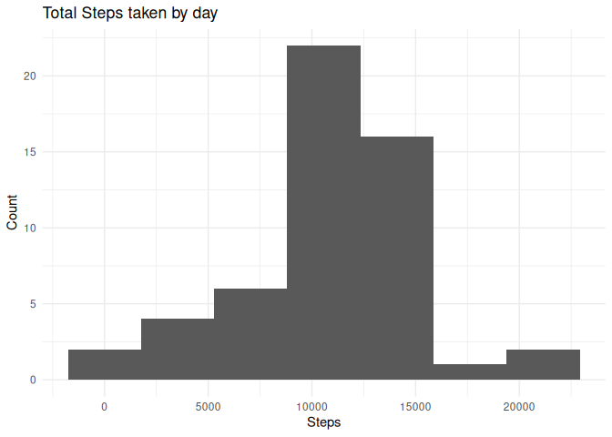

```r
ggplot(steps_day, aes(steps)) +
  geom_histogram(bins=7) +
  labs(title = "Total Steps taken by day",
       x = "Steps",
       y = "Count") +
  theme_minimal()
```

The mean and median of total number of steps cam be taken in different ways. The *summary* command:

```r
summary(steps_day$steps)
```

```
##    Min. 1st Qu.  Median    Mean 3rd Qu.    Max.
##      41    8841   10765   10766   13294   21194
```

Or using a command for each information:

- *mean()* - with result: 1.0766189^{4}
- *median()* - with result: 10765

## Are there differences in activity patterns between weekdays and weekends?

Creating a new factor variable for weekdays and weekends:

```r
saturday <- min(filled_dataset$date) - 2
sunday <- min(filled_dataset$date) - 1
filled_dataset$day_type <- (as.integer(filled_dataset$date - saturday) %% 7 == 0) |
                          (as.integer(filled_dataset$date - sunday) %% 7 == 0)
filled_dataset$day_type <- factor(filled_dataset$day_type,
                                 levels=c(TRUE, FALSE),
                                 labels=c("weekend", "weekday"))
```

To make a plot with the average of number of steps, we have to aggregate de data:

```r
steps_interval_day_type <- aggregate(filled_dataset$steps,
                                     data=filled_dataset,
                                     by=list(filled_dataset$day_type,
                                             filled_dataset$interval),
                                     FUN=mean)
colnames(steps_interval_day_type) <- c("day_type", "interval", "steps")
```

Now, let’s plot the time series. It can be side by side:

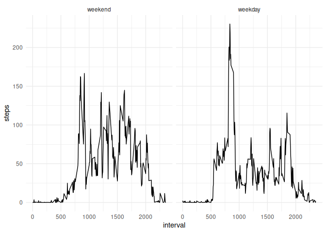

```r
ggplot(steps_interval_day_type, aes(x=interval, y=steps)) +
  geom_line() +
  facet_wrap(~ day_type) +
  theme_minimal()
```

Different lines:

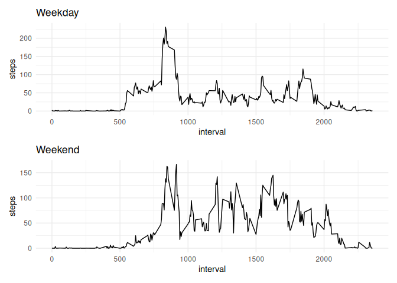

```r
p1 <- ggplot(steps_interval_day_type[steps_interval_day_type$day_type=="weekday",], aes(x=interval, y=steps)) +
  geom_line() +
  labs(title="Weekday") +
  theme_minimal()

p2 <- ggplot(steps_interval_day_type[steps_interval_day_type$day_type=="weekend",], aes(x=interval, y=steps)) +
  geom_line() +
  labs(title="Weekend") +
  theme_minimal()

p1 / p2
```

Or even at the same grid:

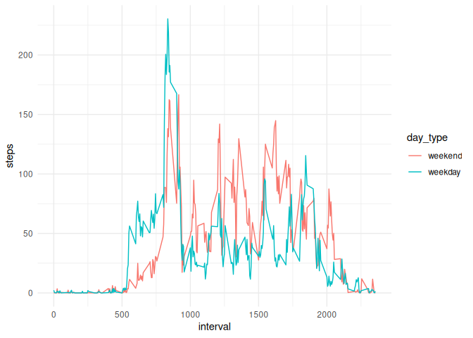

```r
ggplot(steps_interval_day_type, aes(x=interval, y=steps, colour=day_type)) +
  geom_line() +
  theme_minimal()
```